# CSE4502: Assignment 1

**Due**: Fri, April 12, 11:59 PM

**Total Points**: 100

**How to submit**: Create a zip folder named "Assignment1_your name". Include the `.ipynb` file with your answers PLUS its `.html` file as a backup.

**Important**: The places that require your code answer are marked with `"# YOUR CODE"` comments. Do not remove `"# YOUR CODE"`marks.

Good Luck!

## Name: Arianna Azizi

## 1) [5 pts]

A rectified linear activation function or `ReLU` for short,is a simple fuction in deep learning that returns the value provided as input directly, or the value 0.0 if the input is 0.0 or less. Implement the ReLU function in Python.

$$ ReLU(x) = \begin{cases} x, & \text{if } x>0\\ 0, & \text{if } x<=0 \end{cases} $$

```python
def rectified(x):
    # YOUR CODE
    if x <= 0:
        return 0.0
    return x

print(rectified(3))
print(rectified(0))
print(rectified(-3))
```

```
3
0.0
0.0
```

## 2) [15 pts]

Suppose `y_true` and `y_pred` are lists of true class labels and predicted class labels by a classifier respectively. Calculate accuracy **in percent without** using any external libraries like NumPy or scikit-learn.

```python
y_true = [1, 2, 0, 4, 1, 2, 3, 1, 2, 1] #true class labels
y_pred = [1, 2, 1, 4, 1, 0, 3, 1, 2, 1] #predicted class labels


correct = 0
total_elements = len(y_true)
for i, j in zip(y_true, y_pred):
    # YOUR CODE
    if i == j:
        correct += 1



accuracy = (correct/total_elements)*100 # YOUR CODE

print('Accuracy: %.2f%%' % (accuracy))
```

```
Accuracy: 80.00%
```

## 3) [10 pts]

Create a 2x2 NumPy array with random values drawn from a uniform distribution using the random seed `42` and show the results below.

```python
import numpy as np

rng = np.random.RandomState(42)
# YOUR CODE
arr = rng.rand(2, 2)

print(arr)
```

```
[[0.37454012 0.95071431]
 [0.73199394 0.59865848]]
```

## 4) [10 pts]

Use the NumPy slicing syntax to select the 2x2 upper-right corner of `A` matrix.

```
array([[ 1,  2,  3],
       [ 4,  5,  6],
       [ 7,  8,  9]])
```

```python
A = np.array([
    [1, 2, 3],
    [4, 5, 6],
    [7, 8, 9]])

# YOUR CODE
upper_right_2x2 = A[:2, 1:3]
upper_right_2x2
```

```
array([[2, 3],
       [5, 6]])
```

## 5) [10 pts]

Given the array `A` below, use numpy.bincount to find the most frequent integer in that array.

```python
import numpy as np

rng = np.random.RandomState(42)
A = rng.randint(0, 20, 100)
print(repr(A))
# YOUR CODE
# Use numpy.bincount to find the frequency of each integer
counts = np.bincount(A)

# Find the integer with the maximum frequency
most_frequent = np.argmax(counts)

print("The most frequent integer in the array A is:", most_frequent)
```

```
array([ 6, 19, 14, 10,  7,  6, 18, 10, 10,  3,  7,  2,  1, 11,  5,  1,  0,
       11, 11, 16,  9, 15, 14, 14, 18, 11, 19,  2,  4, 18,  6,  8,  6, 17,
        3, 13, 17,  8,  1, 19, 14,  6, 11,  7, 14,  2, 13, 16,  3, 17,  7,
        3,  1,  5,  9,  3, 17, 11,  1,  9,  3, 13, 15, 14,  7, 13,  7, 15,
       12, 17, 14, 12,  8, 14, 12,  0,  6,  8,  0, 11,  7, 10, 18, 16,  7,
        2,  2,  0,  4,  9,  6,  8,  6,  8,  7, 11,  1,  0, 15,  4])
The most frequent integer in the array A is: 7
```

## 6) [20 pts]

Implement a function that calculates balanced accuracy (also called average-per-class-accuracy). You can use any library or function, except the functions that directly calculate confusion matrix or balanced accuracy.

```python
import numpy as np
from sklearn.metrics import confusion_matrix

def balanced_accuracy(y_true, y_predicted):

    # Calculate the confusion matrix values
    tp = 0
    tn = 0
    fp = 0
    fn = 0
    for i in range(len(y_true)):
        if y_true[i] == 1 and y_predicted[i] == 1:
            tp += 1
        # YOUR CODE
        elif y_true[i] == 0 and y_predicted[i] == 0:
            tn += 1
        elif y_true[i] == 1 and y_predicted[i] == 0:
            fn += 1
        elif y_true[i] == 0 and y_predicted[i] == 1:
            fp += 1

    # Calculate Sensitivity and Specificity
    sensitivity = tp / (tp + fn) if (tp + fn) > 0 else 0
    specificity = tn / (tn + fp) if (tn + fp) > 0 else 0

    # Calculate Balanced Accuracy
    balanced_acc = (sensitivity + specificity) / 2


    '''
    # You can compare the values you get with the confusion matrix values from sklearn using:
    tn, fp, fn, tp = confusion_matrix(y_true, y_predicted).ravel()
    '''

    return balanced_acc # YOUR CODE
```

```python
# RUN THIS CELL, BUT DO NOT MODIFY

from sklearn.metrics import balanced_accuracy_score

true_labels = np.array(21*[0] + 69*[1])
predicted_labels = np.array(40*[0] + 50*[1])

print('Balanced accuracy using sklearn: %.2f%%' % (balanced_accuracy_score(true_labels, predicted_labels)))
print('Balanced accuracy using my function: %.2f%%' % (balanced_accuracy(true_labels, predicted_labels)))
```

```
Balanced accuracy using sklearn: 0.86%
Balanced accuracy using my function: 0.86%
```

## 7) [30 pts]

Run the following code and answer the following questions:

#### (a) How does accuracy change with changing the tree maximum depth (line 17)?

The maximum depth (max_depth) of the tree affects the complexity of the model. **If max_depth is set too low**, the decision tree may be too simple to capture the underlying patterns of the data, leading to underfitting, which typically **results in a lower accuracy.**

On the other hand, **setting max_depth too high** can lead to a very complex model that captures noise in the training data rather than the actual signal, **leading to overfitting. When overfitted, the model may show very high accuracy on the training data but poor accuracy on new and unseen data.**

The ideal value for max_depth would balance model complexity and generalization by being high enough to capture relevant patterns but not so high that the model learns the "noise" in the training data.

#### (b) What does the 'min_samples_leaf' parameter represent in a DecisionTreeClassifier according to the sklearn documentation, and how is it connected to the concepts of overfitting or underfitting?

The min_samples_leaf parameter sets the minimum number of samples that are allowed in leaf nodes of the tree. Setting this parameter can help in controlling overfitting:

**Higher values of min_samples_leaf** can lead to simpler, more generalized models because forcing each leaf to have more samples means the tree is less able to learn the fine, possibly noisy, specifics of the training data, therefore reducing overfitting.

**Lower values of min_samples_leaf** allow the tree to make splits that contain fewer samples, which can create a more complex model capable of capturing more information about the data, including noise, potentially leading to overfitting. If set too low, such as 1, the model will likely fit perfectly to the training data, capturing noise and anomalies, and thus not perform well on unseen data.

#### (c) List three additional parameters of a DecisionTreeClassifier as per the sklearn documentation.

**criterion**: This parameter defines the function to measure the quality of a split. Supported criteria are "gini" for the Gini impurity and "entropy" for the information gain.

**splitter**: This parameter defines the strategy used to choose the split at each node. Supported strategies are "best" to choose the best split and "random" to choose the best random split.

**max_features**: This parameter limits the number of features to consider when looking for the best split. It can be an integer (to specify the exact number), a float (to specify a percentage of the total), or one of "auto", "sqrt", or "log2", which are shortcuts for these options based on the number of features.

```
Test accuracy of decision tree classifier on Iris dataset: 0.9777777777777777
```

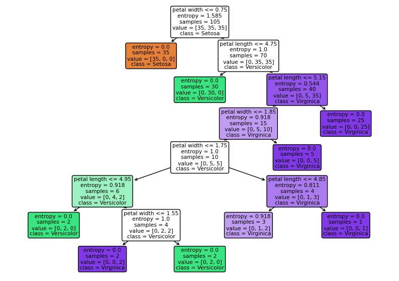

```python
from sklearn import datasets
import numpy as np
from sklearn.model_selection import train_test_split
from sklearn.tree import plot_tree
from sklearn.tree import DecisionTreeClassifier
#added
import sklearn.metrics as metrics
import matplotlib.pyplot as plt


iris = datasets.load_iris()
X = iris.data[:, [2, 3]]
y = iris.target


X_train, X_test, y_train, y_test = train_test_split(
    X, y, test_size=0.3, random_state=1, stratify=y)

tree = DecisionTreeClassifier(criterion='entropy',
                              max_depth=10,
                              random_state=1)
tree.fit(X_train, y_train)

y_pred = tree.predict(X_test)
test_accuracy = metrics.accuracy_score(y_test, y_pred)
print("Test accuracy of decision tree classifier on Iris dataset: "+str(test_accuracy))

plt.figure(figsize=(10, 7))

plot_tree(tree,
          filled=True,
          rounded=True,
          class_names=['Setosa',
                       'Versicolor',
                       'Virginica'],
          feature_names=['petal length',
                         'petal width'])

plt.show()
```